# sfnet_example

This is an example of how to access road network data, how to store and manipulate it using sfnetworks, and how to visualise it using ggplot.

# osmextract

First, we obtain the roads data from OpenStreetMap. We do this using the osmextract package, first exploring which data is available.

```r
#List which providers are available with this version of osmextract
oe_providers()
```

```
## Check the corresponding help pages to read more details about the fields in each database (e.g. ?geofabrik_zones)
```

```
##   available_providers          database_name number_of_zones number_of_fields
## 1           geofabrik        geofabrik_zones             430               14
## 2              bbbike           bbbike_zones             235               10
## 3    openstreetmap_fr openstreetmap_fr_zones             903                6
```

```r
#?geofabrik_zones
class(geofabrik_zones)
```

```
## [1] "sf"         "data.frame"
```

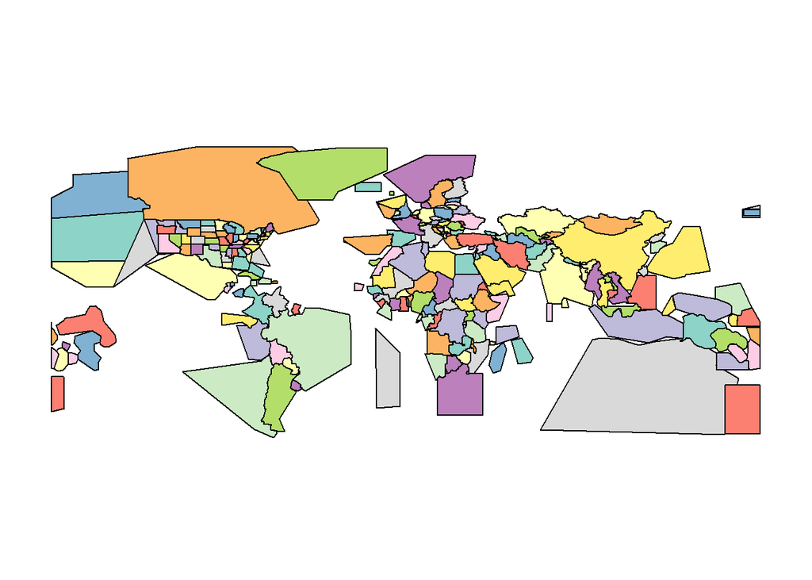

```r
par(mar = rep(0.1, 4))

plot(geofabrik_zones[geofabrik_zones$level == 2, "name"], key.pos = NULL, main = NULL)
```

```r
sa_geofabrik <- oe_match("South Africa", provider = "geofabrik")
```

```
## The input place was matched with: South Africa
```

```r
oe_match_pattern("South Africa")
```

```
## $geofabrik
## [1] "South Africa"                    "South Africa (includes Lesotho)"
##
## $openstreetmap_fr
## [1] "South Africa"
```

I decided to download the data from geofabrik. I’ve commented this out since I’ve already downloaded the data. Note that it is important to convert the data which you get from osm, to .gpkg format.

```r
#Download
#oe_download_directory()

# oe_download(
#   file_url = sa_geofabrik$url,
#   file_size = sa_geofabrik$file_size,
#   provider = "geofabrik",
#   download_directory = "path"
# )

#geofabrik_sa_gpkg = oe_vectortranslate("path/geofabrik_south-africa-latest.osm.pbf")
```

(There are almost certainly ways to do this in R, but I’m a simple person - I need pictures. I like to inspect new data visually in QGIS to make sure all is well!)

# sfnetworks

## Importing and preprocessing data

First, we import the shapefile data. We import both data on administrative units (wards in Gauteng, South Africa) as well as the roads data sourced from OSM. Both the wards and the roads data are now sf objects.

It is not possible to import shapefile data directly as an sfnetworks object. We first import it as an sf object, then do a bit of pre-processing before converting it to an sfnetworks object.

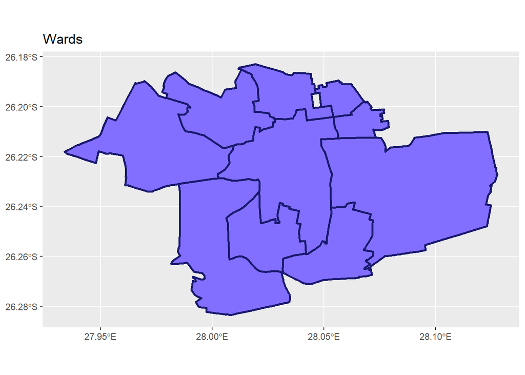

```r
library(ggplot2)

## Import & convert data
wards.wgs <- st_read("E:/_PhD/Wards Paper/OneWardFull/Data/Wards.shp")
roads.data.wgs <- st_read("E:/_PhD/Wards Paper/OneWardFull/Data/Roads.shp")
ggplot() +
  geom_sf(data = wards.wgs, color="midnightblue", size = 1, fill = "slateblue1") +
  ggtitle("Wards")
```

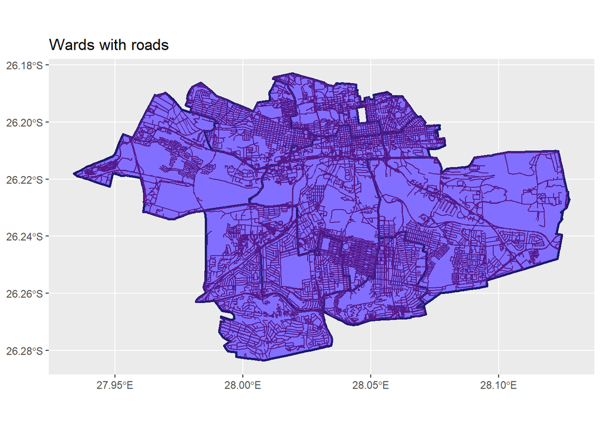

```r
ggplot() +
  geom_sf(data = wards.wgs, color="midnightblue", size = 1, fill = "slateblue1") +
  ggtitle("Wards with roads") +
  geom_sf(data = roads.data.wgs, color="purple4", size = 0.5)
```

After this, we project the data. This is optional, since sfnetworks does not require the data to be in a projection. However, other packages including spatstat do require the data to be projected, so working with projected data makes interoperability easier. But this is up to you as the user. :)

```r
#project data
wards <- st_transform(wards.wgs, 32736)
roads.data <- st_transform(roads.data.wgs, 32736)

roads.data
```

```
## Simple feature collection with 9632 features and 10 fields
## Geometry type: MULTILINESTRING
## Dimension:     XY
## Bounding box:  xmin: -6306.271 ymin: 7083286 xmax: 12883.45 ymax: 7094482
## Projected CRS: WGS 84 / UTM zone 36S
## First 10 features:
##       osm_id code        fclass                  name  ref oneway maxspeed
## 1   34654593 5122   residential         Fawcus Street <NA>      B        0
## 2   34654624 5122   residential          Doran Street <NA>      B        0
## 3   61238785 5122   residential       Marshall Street <NA>      B        0
## 4  543187780 5114     secondary          Jules Street <NA>      B        0
## 5    4334924 5113       primary   Commissioner Street  R24      F        0
## 6    4339844 5113       primary Albertina Sisulu Road  R24      F        0
## 7    4339881 5113       primary Albertina Sisulu Road  R24      B        0
## 8    4339883 5113       primary Albertina Sisulu Road  R24      F       60
## 9    4343386 5133  primary_link                  <NA> <NA>      F        0
## 10  12467715 5131 motorway_link                  <NA> <NA>      F        0
##    layer bridge tunnel                       geometry
## 1      0      F      F MULTILINESTRING ((7720.807 ...
## 2      0      F      F MULTILINESTRING ((7980.331 ...
## 3      0      F      F MULTILINESTRING ((7379.554 ...
## 4      0      F      F MULTILINESTRING ((7968.916 ...
## 5      0      F      F MULTILINESTRING ((5739.773 ...
## 6      0      F      F MULTILINESTRING ((5972.85 7...
## 7      0      F      F MULTILINESTRING ((5972.85 7...
## 8      0      F      F MULTILINESTRING ((6853.049 ...
## 9      1      T      F MULTILINESTRING ((5537.73 7...
## 10     0      F      F MULTILINESTRING ((7308.747 ...
```

For this analysis, I decided to keep only certain types of roads. The chunk below filters the sf object appropriately (to keep only main roads).

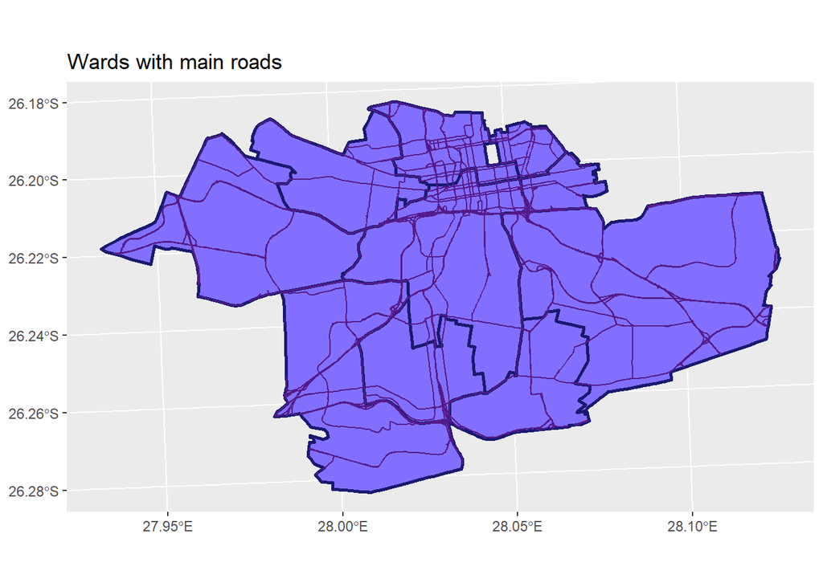

```r
wanted_roads<-c("motorway","motorway_link","primary","primary_link",
                "secondary","secondary_link","tertiary","tertiary_link",
                "trunk","trunk_link")
roads.data<-roads.data[roads.data$fclass %in% wanted_roads,]

ggplot() +
  geom_sf(data = wards, color="midnightblue", size = 1, fill = "slateblue1") +
  ggtitle("Wards with main roads") +
  geom_sf(data = roads.data, color="purple4", size = 0.5) +
  coord_sf()
```

Now that we have the roads we want, we are ready to conver to sfnetworks - right? Not yet! sfnetworks does not like multilinestrings. We first have to cast the data to linestring. This will give a warning stating that the attributes are being repeated for all sub-geometries, and that this may not be accurate. (For example, if a multilinestring has a given speed limit associated with it, the linestrings will each have that speed limit.) In our case, this makes sense, and so we do not spend too much time worrying about the warning.

```r
roads.data.lines <- st_cast(roads.data, "LINESTRING")
```

```
## Warning in st_cast.sf(roads.data, "LINESTRING"): repeating attributes for all
## sub-geometries for which they may not be constant
```

Are we there yet…? Not quite! The final step before converting the sf object to an sfnetworks object is to round the coordinates. It can happen that line endpoints that really should be touching, are in slightly different places due to some error during data capturing. Reducing the precision of coordinates will ensure that they are in the same place, thereby allowing sfnetworks to connect the lines.

```r
st_geometry(roads.data.lines) = st_geometry(roads.data.lines) %>%
  lapply(function(x) round(x, 0)) %>%
  st_sfc(crs = st_crs(roads.data.lines))
```

## Convert to sfnetworks

Once the geometry is linestring and coordinate precision has been reduced, we convert the road network (currently an sf object) to an sfnetworks object. Note the options used in this case.

Setting directed=FALSE means that we are creating an undirected graph. OSM does not typically contain directionality data in a way that can readily be transferred to a graph. Additionally, road networks typically are undirected, with roads being two-way.

(P.S.: If you want to include both one- and two-way roads, you will have to create a directed graph, and include two edges for each two-way road - one in each direction. This can absolutely be done, but we won’t do it here.)

Setting length_as_weight=TRUE means that we include a weight column to the object, and that the weight column is equal to the length of the segments. This should technically not be done before data cleaning (and hence that version has been commented out). The reason is that, once we begin to clean the data, we will be splitting some lines and joining others together, thereby changing the length of the road segments. A better approach is to re-create the cleaned sfnetworks object at the end of the cleaning process, and then specify length as weight. This is the approach we will be taking.

```r
roads <- as_sfnetwork(roads.data.lines, directed = FALSE)

#roads <- as_sfnetwork(roads.data.lines, directed = FALSE, length_as_weight = TRUE)

roads
```

```
## # A sfnetwork with 2431 nodes and 2268 edges
## #
## # CRS:  EPSG:32736
## #
## # An undirected multigraph with 294 components with spatially explicit edges
## #
## # Node Data:     2,431 x 1 (active)
## # Geometry type: POINT
## # Dimension:     XY
## # Bounding box:  xmin: -6109 ymin: 7083790 xmax: 12883 ymax: 7094481
##         geometry
##      <POINT [m]>
## 1 (7969 7092206)
## 2 (7920 7092197)
## 3 (7887 7092192)
## 4 (7817 7092180)
## 5 (7804 7092178)
## 6 (7658 7092153)
## # ... with 2,425 more rows
## #
## # Edge Data:     2,268 x 13
## # Geometry type: LINESTRING
## # Dimension:     XY
## # Bounding box:  xmin: -6109 ymin: 7083790 xmax: 12883 ymax: 7094481
##    from    to osm_id  code fclass name  ref   oneway maxspeed layer bridge
##   <int> <int> <chr>  <int> <chr>  <chr> <chr> <chr>     <int> <dbl> <chr>
## 1     1     2 54318~  5114 secon~ Jule~ <NA>  B             0     0 F
## 2     3     4 54318~  5114 secon~ Jule~ <NA>  B             0     0 F
## 3     5     6 54318~  5114 secon~ Jule~ <NA>  B             0     0 F
## # ... with 2,265 more rows, and 2 more variables: tunnel <chr>,
## #   geometry <LINESTRING [m]>
```

## Data cleaning

### 1. Simplify

The first data cleaning step is to simplify the road network. This changes the graph from a multigraph to a simple graph, which is required for many graph operations.

```r
simple = roads %>%
  activate("edges") %>%
  arrange(edge_length()) %>%
  filter(!edge_is_multiple()) %>%
  filter(!edge_is_loop())

simple
```

```
## # A sfnetwork with 2431 nodes and 2261 edges
## #
## # CRS:  EPSG:32736
## #
## # An undirected simple graph with 294 components with spatially explicit edges
## #
## # Edge Data:     2,261 x 13 (active)
## # Geometry type: LINESTRING
## # Dimension:     XY
## # Bounding box:  xmin: -6109 ymin: 7083790 xmax: 12883 ymax: 7094481
##    from    to osm_id  code fclass name  ref   oneway maxspeed layer bridge
##   <int> <int> <chr>  <int> <chr>  <chr> <chr> <chr>     <int> <dbl> <chr>
## 1   498   499 54233~  5134 secon~ <NA>  <NA>  F             0     0 F
## 2  1128  1129 54261~  5114 secon~ Vick~ <NA>  F             0     0 F
## 3  1326  1327 80066~  5115 terti~ Coll~ <NA>  F            60     0 F
## 4  1860  1953 76825~  5115 terti~ Ntem~ <NA>  B             0     0 F
## 5   120   150 62323~  5114 secon~ Appo~ <NA>  B             0     0 F
## 6  1993  1994 26387~  5131 motor~ <NA>  <NA>  F             0     0 F
## # ... with 2,255 more rows, and 2 more variables: tunnel <chr>,
## #   geometry <LINESTRING [m]>
## #
## # Node Data:     2,431 x 1
## # Geometry type: POINT
## # Dimension:     XY
## # Bounding box:  xmin: -6109 ymin: 7083790 xmax: 12883 ymax: 7094481
##         geometry
##      <POINT [m]>
## 1 (7969 7092206)
## 2 (7920 7092197)
## 3 (7887 7092192)
## # ... with 2,428 more rows
```

### 2. Subdivide

```r
subdivision = convert(simple, to_spatial_subdivision)
```

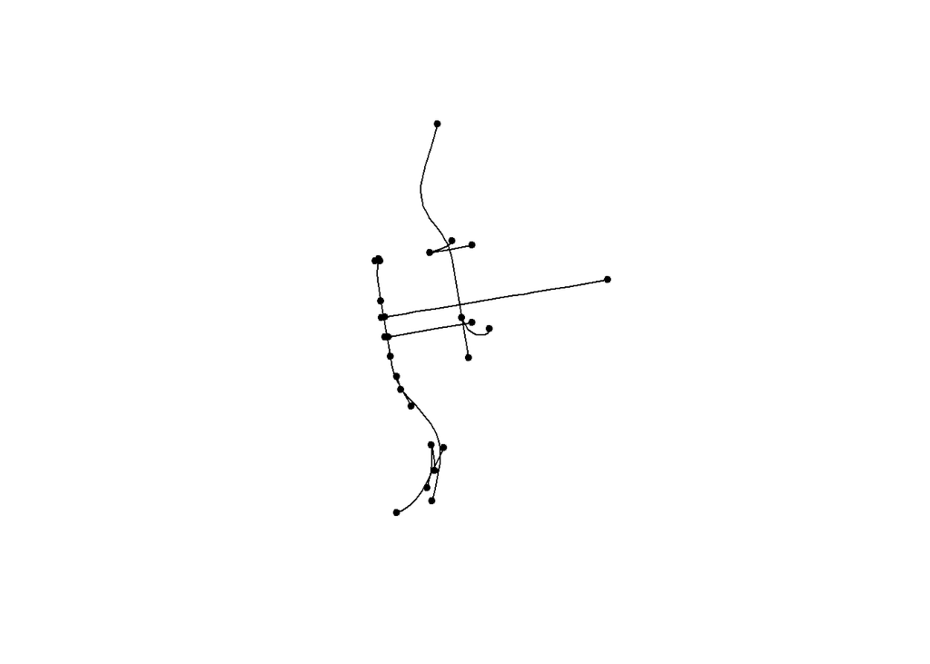

```r
overpasses = subdivision %>%
  activate("edges") %>%
  st_filter(wards[1,], .predicate = st_intersects) %>%
  filter(edge_crosses(.E())) %>%
  activate ("nodes") %>%
  filter(!node_is_isolated())
plot(overpasses)
```

### 3. Smooth pseudo nodes

Next, we smooth away pseudo nodes in order to reduce complexity. Pseudo nodes are nodes that do not define the connectivity of the road network - that is to say, removing the node will not change the connectivity. This is an optional step, since pseudo-nodes might define sections of a road that have different attribute values (e.g. different speed limits). In this case however, we are not concerned with the possibility of losing some attribute information, so we go ahead.

```r
smoothed = convert(subdivision, to_spatial_smooth)
```

### 4. Simplify intersections

Finally, we simplify intersections. It can happen that the endpoints of lines at a 4-way intersection do not quite meet, and that their endpoints are therefore stored as separate nodes connected by short edges.

First, we cluster the nodes using the dbscan method, which clusters points in Euclidean space.

```r
library(dbscan)

# Retrieve the coordinates of the nodes.
node_coords = smoothed %>%
  activate("nodes") %>%
  st_coordinates()

# Cluster the nodes with the DBSCAN spatial clustering algorithm.
# We set eps = 1 such that:
# Nodes within a distance of 1 from each other will be in the same cluster.
# We set minPts = 1 such that:
# A node is assigned a cluster even if it is the only member of that cluster.
clusters = dbscan(node_coords, eps = 1, minPts = 1)$cluster

# Add the cluster information to the nodes of the network.
clustered = smoothed %>%
  activate("nodes") %>%
  mutate(cls = clusters)
```

Since nodes that are close in Euclidean space may not be connected on the network, the second step is to verify that these clustered nodes are in fact connected on the network.

```r
clustered = clustered %>%
  mutate(cmp = group_components())
```

```r
contracted = convert(
  clustered,
  to_spatial_contracted,
  cls, cmp,
  simplify = TRUE
)
```

### 5. Re-create sfnetworks object

Now that our road network has been downloaded from OSM, projected, pulled into sfnetworks and cleaned, only one step remains: accurately calculating edge weights. This is specific to our application - you may not want to use lengths as weights, in which case you can skip this step.

First, we convert the road network from the last step into an sf object. We then convert it back to sfnetworks, this time using the length_as_weight=TRUE option.

```r
contracted.sf <- contracted %>%
  activate("edges") %>%
  st_as_sf()
roads.clean <- as_sfnetwork(contracted.sf, directed = FALSE, length_as_weight = TRUE)
```

For comparison, we visualise the results of data cleaning on one of the wards. Note that the cleaned road network is much cleaner; however, it is technically possible that apparent mistakes may occur.

We also compare the number of nodes and edges between the original and clean roads.

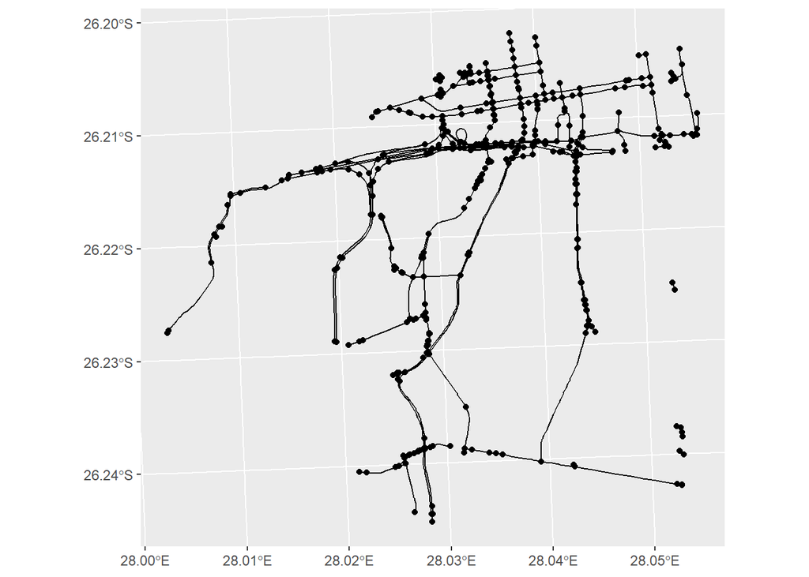

```r
roads.orig.1 <- roads %>%
  activate("nodes") %>%
  st_filter(wards[10,], .predicate = st_intersects) %>%
  filter(!node_is_isolated()) %>%
  activate("edges")
autoplot(roads.orig.1)
```

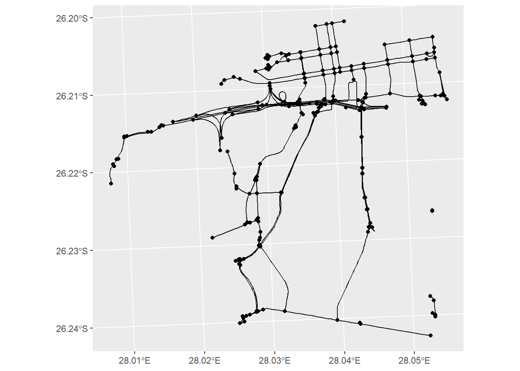

```r
roads.clean.1 <- roads.clean %>%
  activate("nodes") %>%
  st_filter(wards[10,], .predicate = st_intersects) %>%
  filter(!node_is_isolated()) %>%
  activate("edges")
autoplot(roads.clean.1)
```

```r
roads
```

```
## # A sfnetwork with 2431 nodes and 2268 edges
## #
## # CRS:  EPSG:32736
## #
## # An undirected multigraph with 294 components with spatially explicit edges
## #
## # Node Data:     2,431 x 1 (active)
## # Geometry type: POINT
## # Dimension:     XY
## # Bounding box:  xmin: -6109 ymin: 7083790 xmax: 12883 ymax: 7094481
##         geometry
##      <POINT [m]>
## 1 (7969 7092206)
## 2 (7920 7092197)
## 3 (7887 7092192)
## 4 (7817 7092180)
## 5 (7804 7092178)
## 6 (7658 7092153)
## # ... with 2,425 more rows
## #
## # Edge Data:     2,268 x 13
## # Geometry type: LINESTRING
## # Dimension:     XY
## # Bounding box:  xmin: -6109 ymin: 7083790 xmax: 12883 ymax: 7094481
##    from    to osm_id  code fclass name  ref   oneway maxspeed layer bridge
##   <int> <int> <chr>  <int> <chr>  <chr> <chr> <chr>     <int> <dbl> <chr>
## 1     1     2 54318~  5114 secon~ Jule~ <NA>  B             0     0 F
## 2     3     4 54318~  5114 secon~ Jule~ <NA>  B             0     0 F
## 3     5     6 54318~  5114 secon~ Jule~ <NA>  B             0     0 F
## # ... with 2,265 more rows, and 2 more variables: tunnel <chr>,
## #   geometry <LINESTRING [m]>
```

```r
roads.clean
```

```
## # A sfnetwork with 1328 nodes and 1779 edges
## #
## # CRS:  EPSG:32736
## #
## # An undirected simple graph with 41 components with spatially explicit edges
## #
## # Node Data:     1,328 x 1 (active)
## # Geometry type: POINT
## # Dimension:     XY
## # Bounding box:  xmin: -6109 ymin: 7083790 xmax: 12883 ymax: 7094481
##          geometry
##       <POINT [m]>
## 1 (-3655 7088884)
## 2 (-3654 7088883)
## 3  (8747 7086567)
## 4  (8747 7086565)
## 5 (-1976 7093792)
## 6 (-1976 7093794)
## # ... with 1,322 more rows
## #
## # Edge Data:     1,779 x 15
## # Geometry type: LINESTRING
## # Dimension:     XY
## # Bounding box:  xmin: -6109 ymin: 7083790 xmax: 12883 ymax: 7094481
##    from    to osm_id  code fclass name  ref   oneway maxspeed layer bridge
##   <int> <int> <chr>  <int> <chr>  <chr> <chr> <chr>     <int> <dbl> <chr>
## 1     1     2 26387~  5131 motor~ <NA>  <NA>  F             0     0 F
## 2     3     4 95200~  5115 terti~ Neph~ <NA>  B             0     0 F
## 3     5     6 53336~  5134 secon~ <NA>  <NA>  F             0     0 F
## # ... with 1,776 more rows, and 4 more variables: tunnel <chr>,
## #   geometry <LINESTRING [m]>, .tidygraph_edge_index <int>, weight [m]
```

# Visualisation

There are two main ways to visualise sfnetworks objects. The first is by using the autoplot function. This is a great way for obtaining simple visualisations: it shows the road network with its edges and nodes. We have already seen some examples of this.

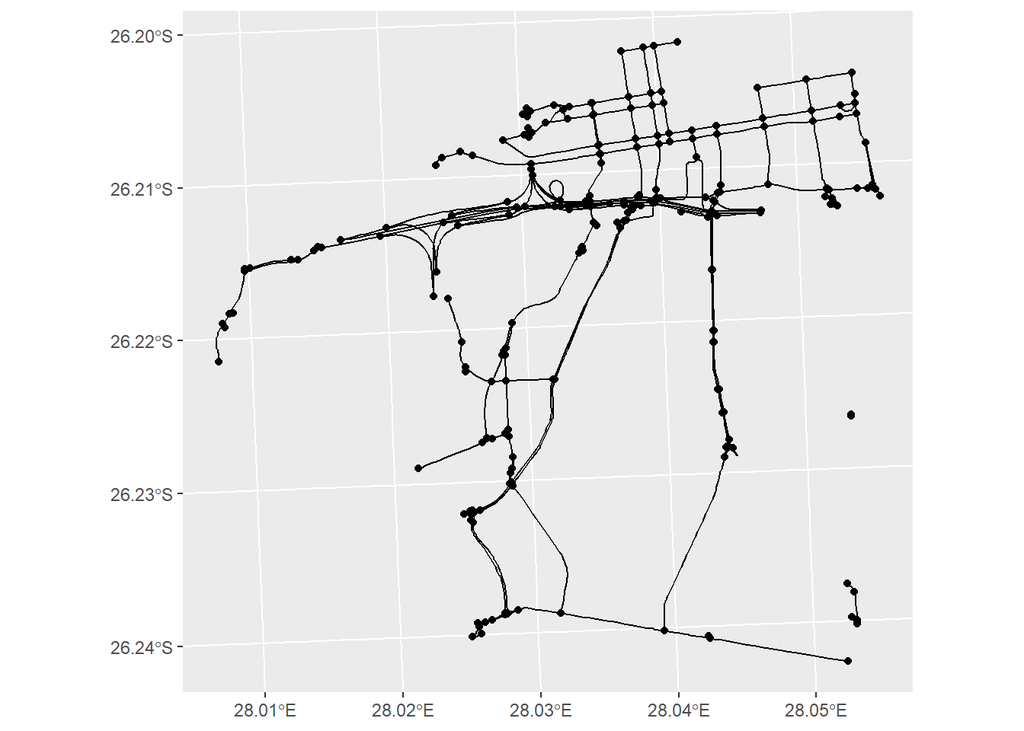

```r
autoplot(roads.clean.1)
```

The autoplot function is quick & easy to use. However, if you want some really nice visualisations, the best way to obtain these is to convert the sfnetworks object into an sf object using the st_as_sf() function, and then use ggplot. At this stage, ggplot does not speak to sfnetworks.

We can overlay the plot of the roads in the above image, over the ward geometry using this approach. Note the importance of activating the correct network element, namely edges instead of nodes.

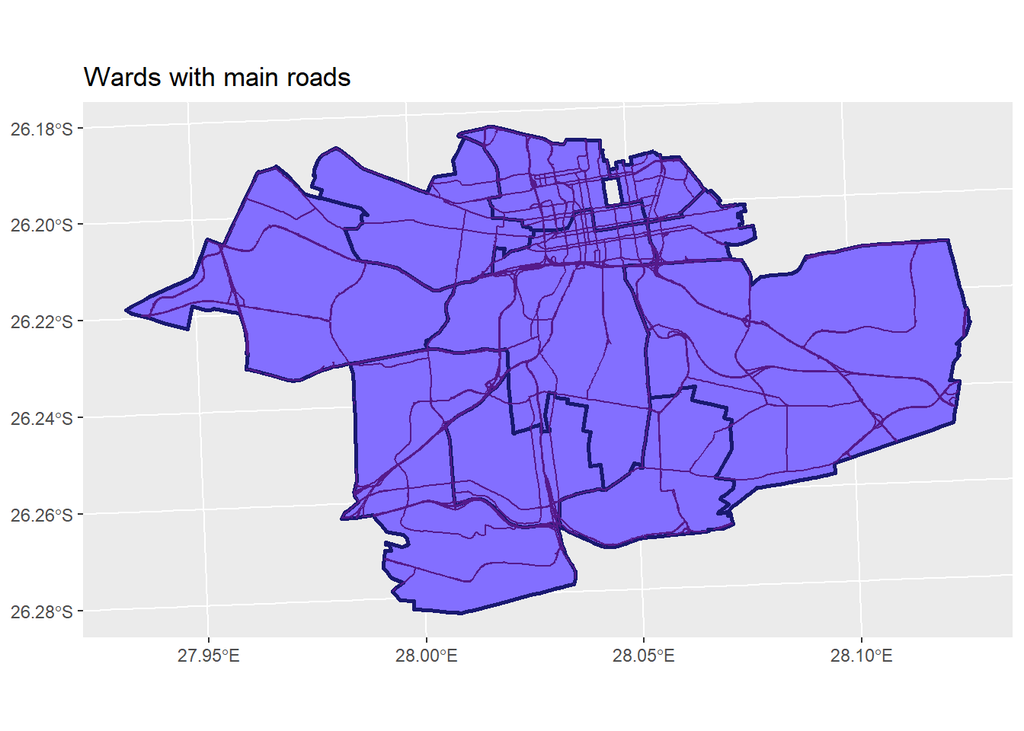

```r
roads.clean.data <- roads.clean %>%
  activate("edges") %>%
  st_as_sf()

ggplot() +
  geom_sf(data = wards, color="midnightblue", size = 1, fill = "slateblue1") +
  ggtitle("Wards with main roads") +
  geom_sf(data = roads.clean.data, color="purple4", size = 0.5)
```

We can of course also plot the nodes, either by themselves or on top of the road network.

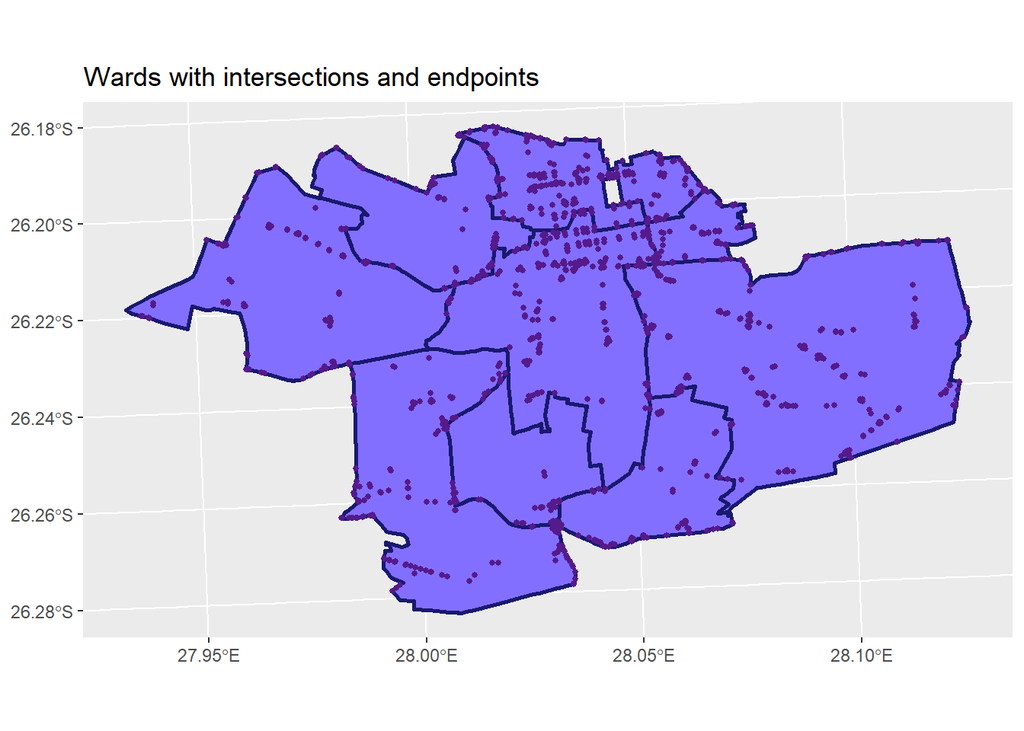

```r
roads.clean.points <- roads.clean %>%
  activate("nodes") %>%
  st_as_sf()

ggplot() +
  geom_sf(data = wards, color="midnightblue", size = 1, fill = "slateblue1") +
  ggtitle("Wards with intersections and endpoints") +
  geom_sf(data = roads.clean.points, color="purple4", size = 1)
```

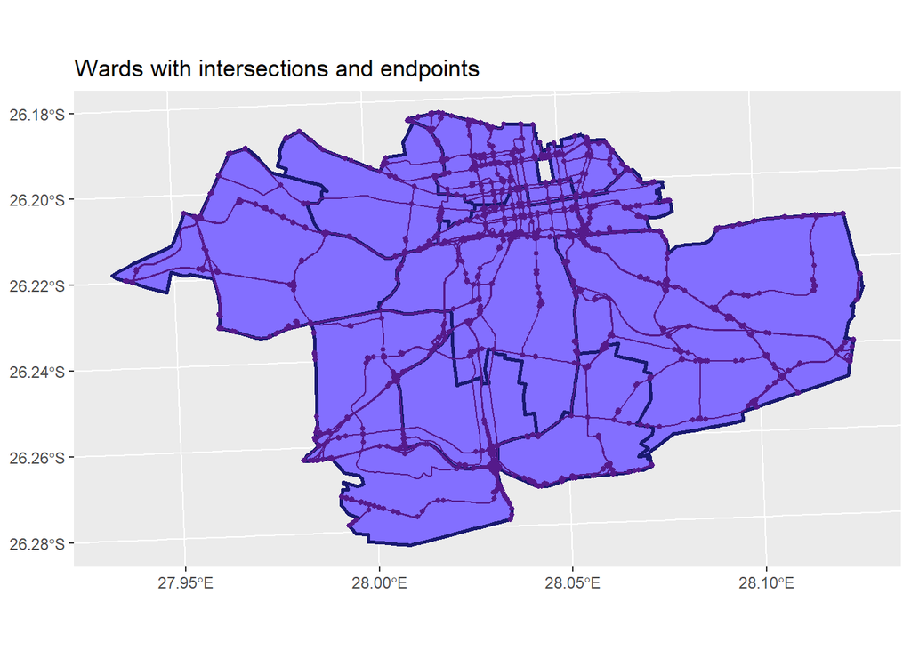

```r
ggplot() +
  geom_sf(data = wards, color="midnightblue", size = 1, fill = "slateblue1") +
  ggtitle("Wards with intersections and endpoints") +
  geom_sf(data = roads.clean.data, color="purple4", size = 0.5) +
  geom_sf(data = roads.clean.points, color="purple4", size = 1)
```

# Applications

Now that we have a clean road network and know how to plot it, it’s time to look at some applications. We will consider two applications that I used in my workflow, namely clustering and routing. As part of my research, I used network clustering to identify clusters of nodes, obtained the centroids of these clusters, and projected them onto the road network. I then calculated the distances between them.

## Clustering

There are various algorithms for clustering nodes on a weighted graph. In the code chunk below, we use Louvain clustering.

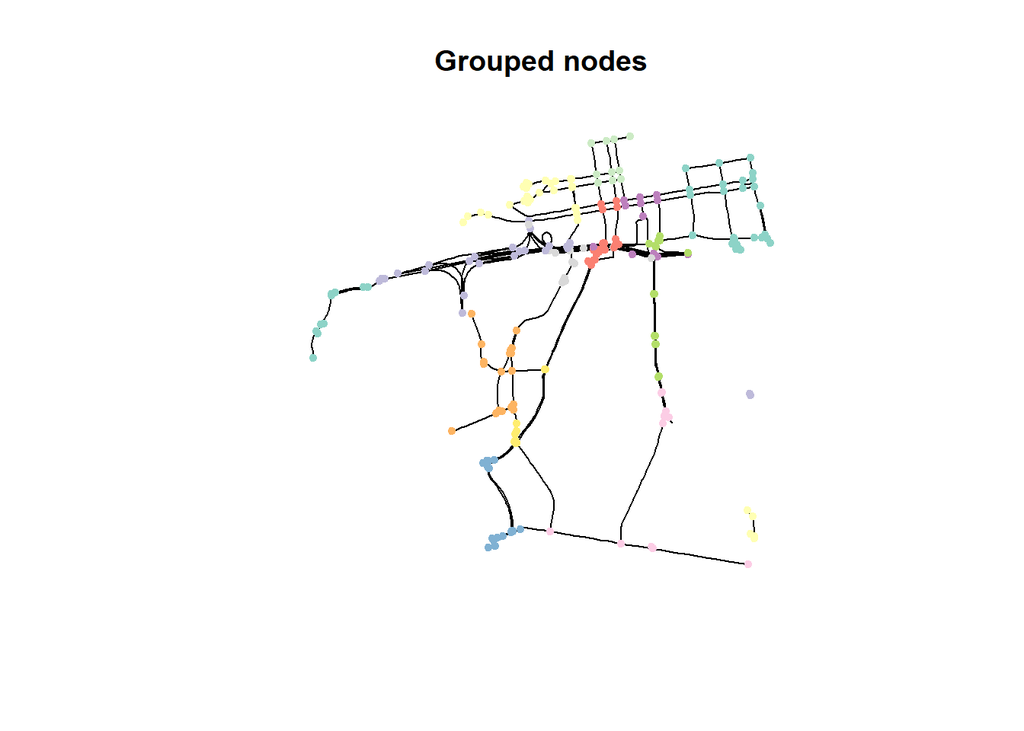

```r
road.louvain <- roads.clean.1 %>%
      activate("nodes") %>%
      mutate(louvain = as.factor(group_louvain()))

plot(st_geometry(road.louvain, "edges"), main = "Grouped nodes")
plot(st_as_sf(road.louvain)["louvain"], key.pos = NULL, pch = 20, add = TRUE)
```

Having obtained the clusters, we now calculate the cluster centroids…

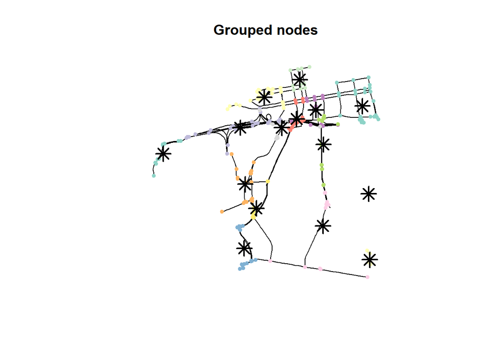

```r
road.louvain.nodes = road.louvain %>%
  activate("nodes") %>%
  st_as_sf()
coords <- as.data.frame(st_coordinates(road.louvain.nodes))
coords$louvain <- road.louvain.nodes$louvain

plot(st_geometry(road.louvain, "edges"), main = "Grouped nodes")
plot(st_as_sf(road.louvain)["louvain"], key.pos = NULL, pch = 20, add = TRUE)

l = length(unique(road.louvain.nodes$louvain))
centroids <- as.data.frame(matrix(c(1:l,rep(0,l*3)),nrow=l,ncol=4))
colnames(centroids) <- c("Group", "X", "Y", "Node")
for (i in 1:l){
  cluster <- coords[coords$louvain==i,]
  #print(cluster)
  centroids[i,2] <- mean(cluster$X)
  centroids[i,3] <- mean(cluster$Y)
  point <- st_sfc(st_point(c(centroids[i,2],centroids[i,3])),crs=32736)
  centroids[i,4] <- st_nearest_feature(point, road.louvain)
  plot(point, pch = 8, cex = 2, lwd = 2, add = TRUE)
}
```

…and project them onto the nearest node on the network. (It is also possible to project points to the nearest edge - details in the GitHub articles.)

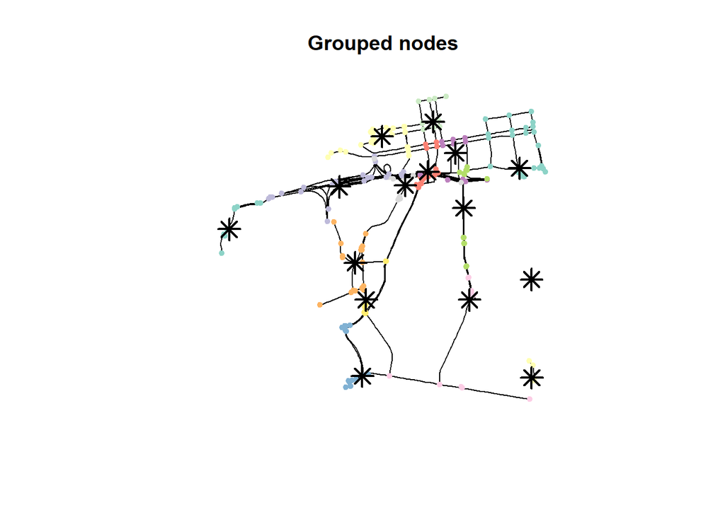

```r
plot(st_geometry(road.louvain, "edges"), main = "Grouped nodes")
plot(st_as_sf(road.louvain)["louvain"], key.pos = NULL, pch = 20, add = TRUE)

for (i in 1:l){
  cpoint <- st_geometry(road.louvain, "nodes")[centroids[i,4]]
  plot(cpoint, pch = 8, cex = 2, lwd = 2, add = TRUE)
}
```

## Routing

sfnetworks supports one-to-one routing and one-to-many routing. It does not support many-to-many routing, but it is able to calculate origin-destination matrices (i.e. many-to-many distances).

```r
OD.centroids <- st_network_cost(roads.clean.1, from=centroids[,4], to=centroids[,4])
```

It is possible to specify different vectors in the from and to arguments, and they need not be of the same dimensions. It is also possible to leave out the from and to arguments. In that case, the distance matrix will be calculated on all the nodes in the supplied network (in our case, 231 nodes).

```r
OD.all <- st_network_cost(roads.clean.1)
```

In the case of one-to-one or one-to-many routing, sfnetworks is able to calculate the exact shortest path between nodes. It is also possible to plot this shortest path. The nodes do not need to be on the network: if they are not, sfnetworks will first project them onto the nearest network node, and then calculate the distance.

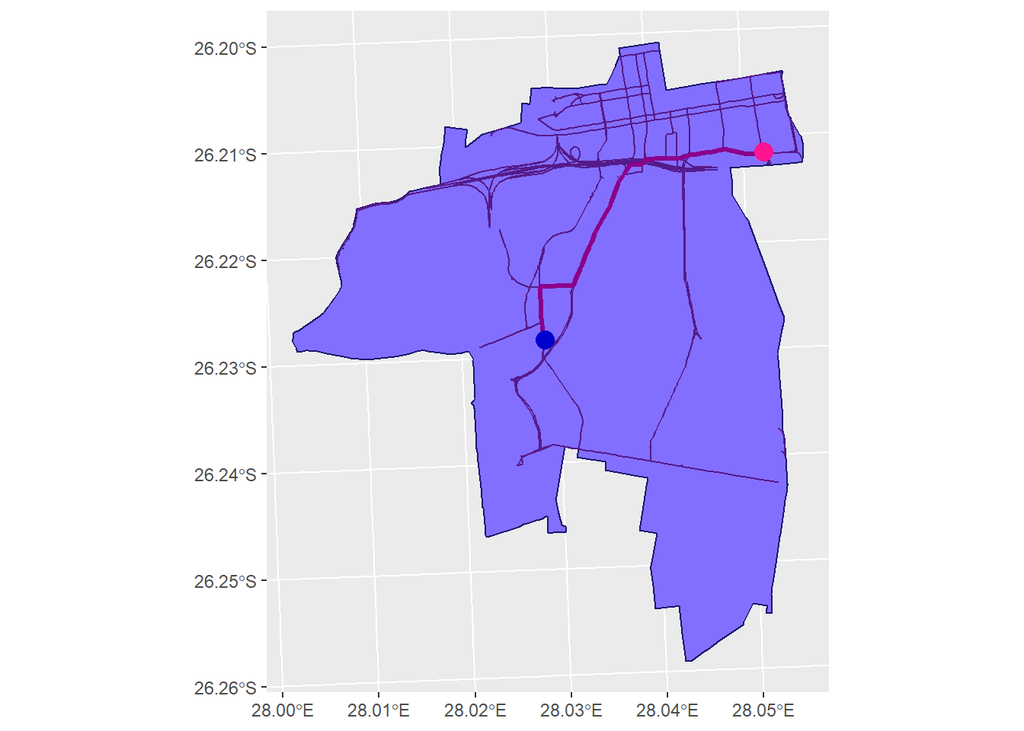

```r
node1 <- st_geometry(roads.clean.1, "nodes")[centroids[1,4]]
node2 <- st_geometry(roads.clean.1, "nodes")[centroids[12,4]]
path = st_network_paths(roads.clean.1, from = node1, to = node2)

edges <- path %>%
  slice(1) %>%
  pull(edge_paths) %>%
  unlist()

plot_path = function(node_path) {
  roads.clean.1 %>%
    activate("nodes") %>%
    slice(node_path) %>%
    plot(cex = 1.5, lwd = 1.5, add = TRUE)
}

ggplot() +
  geom_sf(data = wards[10,], color="midnightblue", size = 0.5, fill = "slateblue1") +
  geom_sf(data = st_as_sf(roads.clean.1, "edges"), col = "purple4") +
  geom_sf(data = st_geometry(roads.clean.1, "edges")[edges],col="magenta4",size=1.2) +
  geom_sf(data = node1,col="deeppink",size=4) +
  geom_sf(data = node2,col="mediumblue",size=4)
```

# Final remarks

There are many more cool applications for sfnetworks! Some of these are showcased in the GitHub articles, including pretty visualisations and comprehensive, easy-to-understand code. The rest is up to you - see where your imagination takes you!